# TAREA 1 - La importancia del cacao en Mexico y en el Mundo

Bruno Axel Santiago Rodriguez

8 de marzo del 2021

NATURALEZA: árbol procedente de América, el fruto del cacao recibe el nombre de “vaina de cacao”, que posee una corteza rugosa de aproximadamente 3 centímetros, esto puede variar dependiendo del origen y variedad de la vaina, este fruto está lleno de una pulpa dulce y mucilagosa, también llamada baba de cacao; Las semillas suelen tener un color blanco, durante el proceso de secado toman un color violeta o marrón rojizo, existen variedades raras de cacao blanco, en donde las semillas permanecen blancas durante este proceso, históricamente, se dice que este tipo de cacao blanco era cultivado en Nicaragua por los pueblos Rama; la semilla fermentada y secada recibe el nombre de grano de cacao, estos se utilizan como ingrediente principal en la elaboración de chocolate, salsa de mole, téjate, etc. La composición del cacao es muy amplia, se puede destacar el alto nivel de energía que aporta, beneficiando a las personas que tienen una intensa actividad física, además cuenta con un alto índice de grasas saturadas, monoinsaturadas y polinsaturadas, hidratos de carbono y proteínas, así como magnesio, fósforo, potasio, teobromina, cafeína, antioxidantes y agua.

VALOR DE USO: se le pueden dar distintos usos, como alimento, lo podemos ver en la elaboración del chocolate, para lo cual se utiliza la grasa que se obtiene al triturar su fruto una vez secado y fermentado, de este fruto se obtiene el polvo de cacao y la manteca de cacao, ambos ingredientes se mezclan junto a azúcares refinados y leche; pueden surgir distintos tipos de chocolate, dependiendo de la cantidad que se utilice de cada ingrediente. La adición de cada uno de estos ingredientes permite que el chocolate tenga más aportes nutritivos, además de los ya presentes en el cacao, como la vitamina A, la vitamina B, el calcio y el hierro. Se puede utilizar como remedio natural, los tratamientos sirven para curar o aliviar el cansancio, la delgadez extrema, la fiebre, los problemas cardiacos, la anemia o los problemas renales e intestinales, todo esto según el Consejo Europeo de Información sobre la Alimentación, su descubrimiento ha permitido el desarrollo de más de cien usos medicinales. Además, se puede utilizar como cosmético, ya que la manteca de cacao sirve como tratamiento para algunos problemas de la piel como las arrugas, las estrías o para el cabello. En nuestro país, Tabasco aporta el 66.9% del total de producción nacional con 17 mil 281 toneladas cosechadas, Chiapas aporta el 32.9% con 9 mil 346 toneladas y Guerrero el 0.2% con 236 toneladas.

VALOR DE CAMBIO: el cacao históricamente en México era utilizado por las tribus Mayas, Aztecas e Incas hace más de 2.500 años, como remedio medicinal y como moneda de cambio, en los primeros años de colonia el cacao seguía siendo utilizado como moneda de cambio en algunas regiones, los conquistadores españoles lo utilizaban para pagarle a los indígenas por su trabajo, un día de trabajo equivalía a 25 cacaos y para salir de la cárcel se cobraban 40 cacaos. En México hay un escaso apoyo al comercio y producción del cacao, lo que produce una baja producción mundial, se puede señalar que, si se incorporaran productos artesanales de mejor calidad, esto haría que se abrieran nuevas redes comerciales y se les daría un valor agregado a estos productos, lo que generaría la conservación la riqueza cultural que acompaña el desarrollo de este cultivo en algunas entidades federativas de nuestro país. Las exportaciones de cacao mexicano son pequeñas, de 621 toneladas exportadas el 79% se destinan a Bélgica, y a empresas norteamericanas de chocolate gourmet quienes buscan el cacao mexicano por su fino aroma que lo hace diferente a otros. El consumo de cacao per cápita en México es de 0.5 kg, representando el 0.6% del gasto total realizado en alimentos y bebidas por las familias mexicanas. La Secretaria de Agricultura estima que para 2030 el consumo y la producción nacional de cacao tenga un crecimiento de 76.97 y 19.49%, respectivamente.

VALOR: en el país existe un déficit de producción y consumo de cacao, esto hace que para satisfacer la demanda interna se importe cacao de Ecuador, Costa de Marfil, República Dominicana, Colombia y Ghana. Cabe señalar que, durante 2016, el valor de las exportaciones de granos de cacao en Ghana ascendió a $621 millones de dólares. Hasta mediados del siglo pasado, los fabricantes solían tostar su propio cacao, además de elaborar productos semi-acabados de cacao; también comercializaban sus propios productos, esta costumbre ha desaparecido casi por completo, en la actualidad, solo se pueden distinguir a dos grupos en la industria cacaotera: elaboradores de productos semi-acabados de cacao y fabricantes de chocolate.

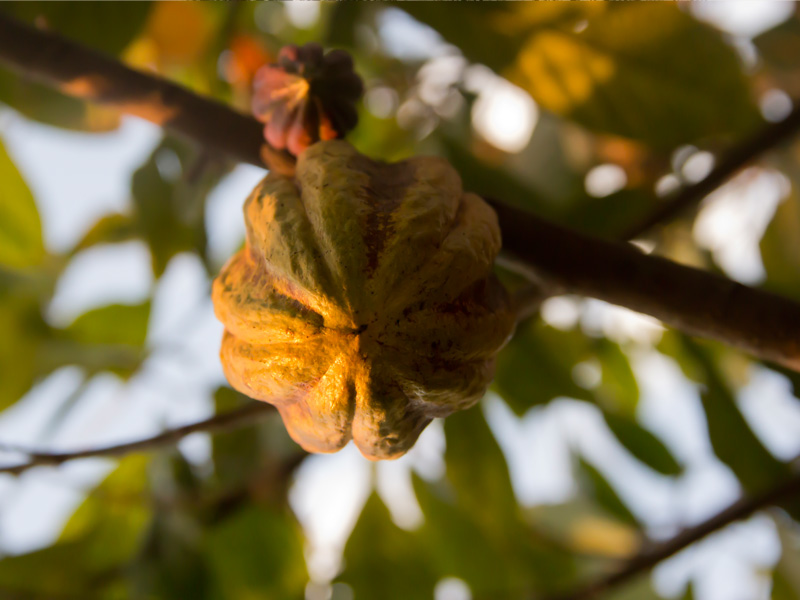

Fuente:Cacao México

## Bibliografía

1. CuidatePlus. (2021). Cacao. 7 de marzo del 2021, de CuidatePlus Sitio web: https://cuidateplus.marca.com/alimentacion/diccionario/cacao.html
2. Cacao México. (2021). Cacao. 8 de marzo del 2021, de Cacao México Sitio web: https://cacaomexico.org/